# Figures + Tables

Icíar Fernández Boyano

April 2023

**On the figures & tables not present in this script:**

- Figure 1 was created in powerpoint
- Figure 2 was created as part of the 01_1_Training.Rmd and 01_2_Training_MinimalModel.Rmd scripts, located in this same folder
- Table 1 was created collecting demographic information from the QC scripts, in 01_Preprocessing/2022_Manuscript_Final_Scripts
- Table 2 was generated as part of the 01_2_Training_MinimalModel.Rmd and 01_3_Training_PermutedModel.Rmd scripts, located in this same folder
- Figure S1 was generated in the GA script in the preprocessing folder
- Table S1 was generated in the GA script in the preprocessing folder
- Table S2 was generated in the predictor analysis script in this folder

# Setup

```r
library(tidyverse)
library(mixOmics)
library(here)
library(tictoc)
library(doParallel)
library(impute)
library(sva)
library(missMethyl)
library(janitor)
library(factoextra)
library(plomics)
library(tidyr)
library(ENmix)
library(cvms)
library(ROCR)
library(ggsci)
library(DescTools)
library(MLmetrics)
library(ENmix)
library(caret)
library(readxl)
library(wateRmelon)
library(planet)
library(ggpubr)
library(rstatix)
library(ggridges)
library(karyoploteR)
library(AnnotationHub)

# PROBE INFO

probeInfo <- cbind(IlluminaHumanMethylation450kanno.ilmn12.hg19::Locations,
                   IlluminaHumanMethylation450kanno.ilmn12.hg19::Manifest,
                      IlluminaHumanMethylation450kanno.ilmn12.hg19::Other) %>% as.data.frame()

probeInfo <- rownames_to_column(probeInfo, var="probeID")

chrXY <- probeInfo %>% filter(chr %in% c("chrX", "chrY"))
chrX <- probeInfo %>% filter(chr %in% c("chrX"))
chrY <- probeInfo %>% filter(chr %in% c("chrY"))

# OBJECTS

complete_mset <- readRDS(here("Data", "01_Raw", "complete_mset.rds"))

x_train <- readRDS(here("Data", "03_Predictor", "x_train.rds"))
y_train <- readRDS(here("Data", "03_Predictor", "y_train.rds"))
trainMeta <- read.csv(here("Data", "03_Predictor", "trainMeta.csv"))

val <- readRDS(here("Data", "02_Processed", "valBMIQ.rds"))
valMeta <- read.csv(here("Data", "02_Processed", "valMeta.csv"))
val <- val[,colnames(val) %in% valMeta$Sample_ID]
all(colnames(val) == valMeta$Sample_ID) # TRUE
```

```
## [1] TRUE
```

```r
exp <- readRDS(here("Data", "02_Processed", "extBMIQ.rds"))
expMeta <- read.csv(here("Data", "02_Processed", "extMeta.csv"))
exp <- exp[,colnames(exp) %in% expMeta$Sample_ID]
all(colnames(exp) == expMeta$Sample_ID) # TRUE
```

```
## [1] TRUE
```

```r
cordblood <- readRDS(here("Data", "02_Processed", "GSE110829_QC_BMIQ_BC.rds"))
cordblood_meta <- read.csv(here("Data", "02_Processed", "GSE110829_metadata.csv"))
all(colnames(cordblood) == cordblood_meta$Sample_ID) # TRUE
```

```
## [1] TRUE
```

```r
# MODEL
set.seed(2022)

tic()
mod <- mixOmics::splsda(x_train,
                        y_train,
                        ncomp = 1,
                        keepX = 45)
toc() # 2.44 sec elapsed
```

```
## 2.44 sec elapsed
```

```r
# predict preeclampsia function
predictPreeclampsia <- function(betas, ...){

  trainCpGs <- colnames(mod$X)
  peCpGs <- mixOmics::selectVar(mod)$name

  # check that there are no NAs in the predictors (or if there are, how many)
  pp <- intersect(colnames(betas), peCpGs)

  if(length(pp) < length(peCpGs)){
    warning(paste(
      "Only", length(pp), "out of 45 predictors present."
    ))
  } else {
    message(paste(length(pp), "of 45 predictors present."))
    message("BMIQ normalization is recommended for best results.")
  }

  # set up data for prediction

  # if input data is missing any of the cpgs present in the training data, this function
  # adds the ones that are missing as NAs
  # necessary for `mixOmics::predict` to work

  outersect = function(x, y) {
    sort(c(x[!x%in%y],
           y[!y%in%x]))
  }

  if(inherits(betas, 'matrix')){
  } else if (inherits(betas, 'array')) {
  } else {

    # throw an error
    print(paste0("Input data must be a matrix or an array"))
  }

  subset <- betas[,colnames(betas) %in% trainCpGs]

  # order
  subset <- subset[drop=FALSE,, trainCpGs]

  if(all(colnames(subset) == trainCpGs) == FALSE){
    stop()
  } else

    # predict
    out <- mixOmics:::predict.mixo_spls(mod, subset)

  # get class probabilities
  CP <- out$predict[,,1]
  CP <- t(apply(as.matrix(CP), 1, function(data) exp(data)/sum(exp(data))))
  CP <- as.data.frame(CP) %>% tibble::rownames_to_column("Sample_ID")
  CP$Pred_Class <- CP$comp1
  CP <- CP %>%
    dplyr::mutate(Pred_Class = dplyr::case_when(EOPE > `Non-PE Preterm` ~ "EOPE",
                                                EOPE < `Non-PE Preterm` ~ "Normotensive"))

  return(CP)
}
```

In this R Markdown, I take code from the other scripts in this folder and put it together to make some better figures for the paper after receiving feedback, since I prefer to leave the analysis scripts as they were.

# Predict EOPE and cell composition

## EOPE

```r
# predict
valpreds <- predictPreeclampsia(t(val))
```

```
## 45 of 45 predictors present.
```

```
## BMIQ normalization is recommended for best results.
```

```r
exppreds <- predictPreeclampsia(t(exp))
```

```
## 45 of 45 predictors present.
## BMIQ normalization is recommended for best results.
```

```r
gc()
```

```
##             used   (Mb) gc trigger    (Mb)   max used    (Mb)
## Ncells  20971776 1120.1   40339125  2154.4   23597932  1260.3
## Vcells 878407921 6701.8 1804325392 13766.0 1707926483 13030.5
```

```r
# quick look
head(valpreds)
```

```
##    Sample_ID      EOPE Non-PE Preterm   Pred_Class
## 1 GSM2589533 0.6699478      0.3300522         EOPE
## 2 GSM2589535 0.7680531      0.2319469         EOPE
## 3 GSM2589536 0.8068395      0.1931605         EOPE
## 4 GSM2589538 0.7843615      0.2156385         EOPE
## 5 GSM2589540 0.3858278      0.6141722 Normotensive
## 6 GSM2589541 0.6488529      0.3511471         EOPE
```

```r
head(exppreds)
```

```
##    Sample_ID      EOPE Non-PE Preterm   Pred_Class
## 1 GSM1388230 0.2363029      0.7636971 Normotensive
## 2 GSM1388231 0.3017699      0.6982301 Normotensive
## 3 GSM1388232 0.2132277      0.7867723 Normotensive
## 4 GSM1388233 0.2611117      0.7388883 Normotensive
## 5 GSM1388234 0.3063391      0.6936609 Normotensive
## 6 GSM1388235 0.2624368      0.7375632 Normotensive
```

```r
# join with metadata
valMeta <- left_join(valMeta, valpreds, by="Sample_ID")
head(valMeta)
```

```
##   X.1  Sample_ID Subject_ID GEO_Dataset    Sex      Condition IUGR Preterm Term
## 1   1 GSM2589533         NA    GSE98224 Female             PE  Yes     Yes   No
## 2   2 GSM2589535         NA    GSE98224 Female             PE  Yes     Yes   No
## 3   3 GSM2589536         NA    GSE98224 Female             PE   No     Yes   No
## 4   4 GSM2589538         NA    GSE98224   Male             PE  Yes     Yes   No
## 5   5 GSM2589540         NA    GSE98224 Female Non-PE Preterm   No     Yes   No
## 6   6 GSM2589541         NA    GSE98224   Male             PE   No     Yes   No
##    PE    GA   GA_RPC Ethnicity Maternal_Age        Chip Row Column
## 1 Yes 29.86 31.19301 Caucasian           40 10005833110 R06    C02
## 2 Yes 31.71 32.66298     Black           38 10005833024 R02    C02
## 3 Yes 29.57 30.29396     Asian           33  9977525015 R03    C01
## 4 Yes 30.71 31.58443 Caucasian           31  9977525015 R06    C01
## 5  No 30.43 31.19843     Asian           35  9977525013 R05    C02
## 6 Yes 30.71 31.64100     Black           32 10005833110 R03    C01
##   Predicted_ethnicity_nothresh Predicted_ethnicity Prob_African Prob_Asian
```

[output cut: 27 more lines]

```r
expMeta <- left_join(expMeta, exppreds, by="Sample_ID")
head(expMeta)
```

```
##   X.1  Sample_ID Subject_ID GEO_Dataset    Sex   Condition    IUGR Preterm Term
## 1   1 GSM1388230       <NA>    GSE57767 Female Non-PE Term Unknown      No  Yes
## 2   2 GSM1388231       <NA>    GSE57767   Male Non-PE Term Unknown      No  Yes
## 3   3 GSM1388232       <NA>    GSE57767 Female Non-PE Term Unknown      No  Yes
## 4   4 GSM1388233       <NA>    GSE57767   Male Non-PE Term Unknown      No  Yes
## 5   5 GSM1388234       <NA>    GSE57767   Male Non-PE Term Unknown      No  Yes
## 6   6 GSM1388235       <NA>    GSE57767 Female Non-PE Term Unknown      No  Yes
##   PE GA   GA_RPC Ethnicity Maternal_Age Chip  Row Column
## 1 No NA 38.37877      <NA>           NA   NA <NA>   <NA>
## 2 No NA 37.79870      <NA>           NA   NA <NA>   <NA>
## 3 No NA 39.21830      <NA>           NA   NA <NA>   <NA>
## 4 No NA 39.56262      <NA>           NA   NA <NA>   <NA>
## 5 No NA 37.95905      <NA>           NA   NA <NA>   <NA>
## 6 No NA 40.59139      <NA>           NA   NA <NA>   <NA>
##   Predicted_ethnicity_nothresh Predicted_ethnicity Prob_African  Prob_Asian
```

[output cut: 27 more lines]

```r
# assess
tabyl(valMeta, Class, Pred_Class) # 15 EOPE misclassified as normotensive
```

```
##           Class EOPE Normotensive
##            EOPE   23           15
##  Non-PE Preterm    2            9
```

```r
tabyl(expMeta, Class, Pred_Class)
```

```
##           Class EOPE Normotensive
##           CPM16    6            4
##            EOPE    2            0
##             FGR   11           35
##          LatePE   27           59
##  Non-PE Preterm    1            2
##     Non-PE Term   21          160
```

## Cell composition

```r
# calculate cell composition for all samples in all three cohorts
data("plCellCpGsThird")
data("plColors")
head(plCellCpGsThird)
```

```
##            Trophoblasts   Stromal  Hofbauer Endothelial      nRBC
## cg10590657    0.1014098 0.9345796 0.8655285   0.8963641 0.8448382
## cg14923398    0.1282030 0.8902107 0.9036769   0.9383641 0.9508709
## cg05348366    0.1305697 0.9519820 0.8803082   0.9065136 0.9278057
## cg17907628    0.1215249 0.9278777 0.8727841   0.8914412 0.9143601
## cg26799656    0.1259953 0.9482014 0.8803863   0.8791004 0.9010419
## cg11862144    0.1561991 0.9430855 0.9114967   0.9341671 0.9647331
##            Syncytiotrophoblast
## cg10590657          0.05460441
## cg14923398          0.05383193
## cg05348366          0.06546727
## cg17907628          0.05325227
## cg26799656          0.06823985
## cg11862144          0.06044207
```

```r
cellcomp_val <-
  minfi:::projectCellType(

    # subset your data to cell cpgs
    val[rownames(plCellCpGsThird),],

    # input the reference cpg matrix
    plCellCpGsThird,

    lessThanOne = FALSE)

cellcomp_val <- as.data.frame(cellcomp_val) %>% rownames_to_column("Sample_ID")
head(cellcomp_val)
```

```
##    Sample_ID Trophoblasts    Stromal     Hofbauer Endothelial       nRBC
## 1 GSM2589533   0.28826381 0.09518812 7.110529e-03  0.05910320 0.04075207
## 2 GSM2589535   0.08966657 0.11266359 0.000000e+00  0.11097521 0.02993964
## 3 GSM2589536   0.12235341 0.14221456 0.000000e+00  0.11470246 0.04085289
## 4 GSM2589538   0.08769428 0.07089516 1.734723e-18  0.09297928 0.03645270
## 5 GSM2589540   0.15870063 0.17083259 0.000000e+00  0.11489561 0.05051507
## 6 GSM2589541   0.10660663 0.12818185 0.000000e+00  0.13257768 0.05465106
##   Syncytiotrophoblast
## 1           0.5214664
## 2           0.6143537
## 3           0.5628919
## 4           0.6837498
## 5           0.5135621
## 6           0.5616915
```

```r
valMeta <- left_join(valMeta, cellcomp_val, by="Sample_ID")
head(valMeta)
```

```
##   X.1  Sample_ID Subject_ID GEO_Dataset    Sex      Condition IUGR Preterm Term
## 1   1 GSM2589533         NA    GSE98224 Female             PE  Yes     Yes   No
## 2   2 GSM2589535         NA    GSE98224 Female             PE  Yes     Yes   No
## 3   3 GSM2589536         NA    GSE98224 Female             PE   No     Yes   No
## 4   4 GSM2589538         NA    GSE98224   Male             PE  Yes     Yes   No
## 5   5 GSM2589540         NA    GSE98224 Female Non-PE Preterm   No     Yes   No
## 6   6 GSM2589541         NA    GSE98224   Male             PE   No     Yes   No
##    PE    GA   GA_RPC Ethnicity Maternal_Age        Chip Row Column
## 1 Yes 29.86 31.19301 Caucasian           40 10005833110 R06    C02
## 2 Yes 31.71 32.66298     Black           38 10005833024 R02    C02
## 3 Yes 29.57 30.29396     Asian           33  9977525015 R03    C01
## 4 Yes 30.71 31.58443 Caucasian           31  9977525015 R06    C01
## 5  No 30.43 31.19843     Asian           35  9977525013 R05    C02
## 6 Yes 30.71 31.64100     Black           32 10005833110 R03    C01
##   Predicted_ethnicity_nothresh Predicted_ethnicity Prob_African Prob_Asian
```

[output cut: 41 more lines]

```r
cellcomp_exp <-
  minfi:::projectCellType(

    # subset your data to cell cpgs
    exp[rownames(plCellCpGsThird),],

    # input the reference cpg matrix
    plCellCpGsThird,

    lessThanOne = FALSE)

cellcomp_exp <- as.data.frame(cellcomp_exp) %>% rownames_to_column("Sample_ID")
head(cellcomp_exp)
```

```
##    Sample_ID Trophoblasts    Stromal     Hofbauer Endothelial       nRBC
## 1 GSM1388230   0.14774413 0.11468234 0.000000e+00  0.11226456 0.03289885
## 2 GSM1388231   0.04603794 0.09236433 0.000000e+00  0.07742429 0.03774001
## 3 GSM1388232   0.12885038 0.13256146 1.734723e-18  0.10592365 0.02596195
## 4 GSM1388233   0.07409208 0.12621794 9.440295e-04  0.10233357 0.03438241
## 5 GSM1388234   0.21436727 0.13254118 0.000000e+00  0.12832243 0.02490727
## 6 GSM1388235   0.11345788 0.11825866 5.096983e-04  0.10381722 0.03393380
##   Syncytiotrophoblast
## 1           0.6150695
## 2           0.7589848
## 3           0.6262584
## 4           0.6888208
## 5           0.5086337
## 6           0.6544039
```

```r
expMeta <- left_join(expMeta, cellcomp_exp, by="Sample_ID")
head(expMeta)
```

```
##   X.1  Sample_ID Subject_ID GEO_Dataset    Sex   Condition    IUGR Preterm Term
## 1   1 GSM1388230       <NA>    GSE57767 Female Non-PE Term Unknown      No  Yes
## 2   2 GSM1388231       <NA>    GSE57767   Male Non-PE Term Unknown      No  Yes
## 3   3 GSM1388232       <NA>    GSE57767 Female Non-PE Term Unknown      No  Yes
## 4   4 GSM1388233       <NA>    GSE57767   Male Non-PE Term Unknown      No  Yes
## 5   5 GSM1388234       <NA>    GSE57767   Male Non-PE Term Unknown      No  Yes
## 6   6 GSM1388235       <NA>    GSE57767 Female Non-PE Term Unknown      No  Yes
##   PE GA   GA_RPC Ethnicity Maternal_Age Chip  Row Column
## 1 No NA 38.37877      <NA>           NA   NA <NA>   <NA>
## 2 No NA 37.79870      <NA>           NA   NA <NA>   <NA>
## 3 No NA 39.21830      <NA>           NA   NA <NA>   <NA>
## 4 No NA 39.56262      <NA>           NA   NA <NA>   <NA>
## 5 No NA 37.95905      <NA>           NA   NA <NA>   <NA>
## 6 No NA 40.59139      <NA>           NA   NA <NA>   <NA>
##   Predicted_ethnicity_nothresh Predicted_ethnicity Prob_African  Prob_Asian
```

[output cut: 41 more lines]

```r
dim(train <- complete_mset[,colnames(complete_mset) %in% trainMeta$Sample_ID])
```

```
## [1] 485512     83
```

```r
all(colnames(train) == trainMeta$Sample_ID) # TRUE
```

```
## [1] TRUE
```

```r
set.seed(2022)
tic()
train <- wateRmelon::BMIQ(train)
toc()
```

```
## 414.72 sec elapsed
```

```r
cellcomp_train <-
  minfi:::projectCellType(

    # subset your data to cell cpgs
    train[rownames(plCellCpGsThird),],

    # input the reference cpg matrix
    plCellCpGsThird,

    lessThanOne = FALSE)

cellcomp_train <- as.data.frame(cellcomp_train) %>% rownames_to_column("Sample_ID")
head(cellcomp_train)
```

```
##    Sample_ID Trophoblasts    Stromal      Hofbauer Endothelial       nRBC
## 1 GSM1388241    0.1949273 0.18881034  3.017036e-02  0.13931013 0.02764368
## 2 GSM1388242    0.1309404 0.11600744  1.369842e-02  0.06997612 0.05942158
## 3 GSM1388243    0.1432053 0.10063849  7.636605e-03  0.10047835 0.04963739
## 4 GSM1388259    0.1637914 0.10621919  0.000000e+00  0.12511270 0.03842731
## 5 GSM1388262    0.3327422 0.11365620  3.469447e-18  0.14686518 0.02617600
## 6 GSM1388266    0.2520346 0.05088609 -3.469447e-18  0.09243905 0.01275529
##   Syncytiotrophoblast
## 1           0.4250851
## 2           0.6228808
## 3           0.6333450
## 4           0.5770393
## 5           0.3707992
## 6           0.5715851
```

```r
trainMeta <- left_join(trainMeta, cellcomp_train, by="Sample_ID")
head(trainMeta)
```

```
##            X  Sample_ID Subject_ID GEO_Dataset    Sex      Condition    IUGR
## 1 GSM1388241 GSM1388241       <NA>    GSE57767   Male Non-PE Preterm Unknown
## 2 GSM1388242 GSM1388242       <NA>    GSE57767 Female Non-PE Preterm Unknown
## 3 GSM1388243 GSM1388243       <NA>    GSE57767   Male Non-PE Preterm Unknown
## 4 GSM1388259 GSM1388259       <NA>    GSE57767   Male             PE Unknown
## 5 GSM1388262 GSM1388262       <NA>    GSE57767   Male             PE Unknown
## 6 GSM1388266 GSM1388266       <NA>    GSE57767 Female             PE Unknown
##   Preterm Term  PE GA   GA_RPC Ethnicity Maternal_Age Chip  Row Column
## 1     Yes   No  No NA 35.87492      <NA>           NA   NA <NA>   <NA>
## 2     Yes   No  No NA 36.28301      <NA>           NA   NA <NA>   <NA>
## 3     Yes   No  No NA 36.07620      <NA>           NA   NA <NA>   <NA>
## 4     Yes   No Yes NA 33.62615      <NA>           NA   NA <NA>   <NA>
## 5     Yes   No Yes NA 29.30807      <NA>           NA   NA <NA>   <NA>
## 6     Yes   No Yes NA 30.92914      <NA>           NA   NA <NA>   <NA>
##   Predicted_ethnicity_nothresh Predicted_ethnicity Prob_African  Prob_Asian
```

[output cut: 20 more lines]

# Classification performance: probability & categorical predictions (Figure 3)

```r
dim(valMeta)
```

```
## [1] 49 45
```

```r
dim(expMeta)
```

```
## [1] 328  45
```

```r
dim(valMeta <- valMeta %>% dplyr::select(!c(Syncytiotrophoblast.x, Trophoblasts.x, Stromal.x, Hofbauer.x, Endothelial.x, nRBC.x,
                                            meanSScor, FAIL_Intersample_Cor)) %>% dplyr::rename(Syncytiotrophoblast = Syncytiotrophoblast.y,
                                                                                         Trophoblasts = Trophoblasts.y,
                                                                                         Stromal = Stromal.y,
                                                                                         Hofbauer = Hofbauer.y,
                                                                                         Endothelial = Endothelial.y,
                                                                                         nRBC = nRBC.y))
```

```
## [1] 49 37
```

```r
dim(expMeta <- expMeta %>% dplyr::select(!c(Syncytiotrophoblast.x, Trophoblasts.x, Stromal.x, Hofbauer.x, Endothelial.x, nRBC.x,
                                            meanSScor, FAIL_Intersample_Cor)) %>% dplyr::rename(Syncytiotrophoblast = Syncytiotrophoblast.y,
                                                                                         Trophoblasts = Trophoblasts.y,
                                                                                         Stromal = Stromal.y,
                                                                                         Hofbauer = Hofbauer.y,
                                                                                         Endothelial = Endothelial.y,
                                                                                         nRBC = nRBC.y))
```

```
## [1] 328  37
```

```r
all(colnames(valMeta) == colnames(expMeta)) # TRUE
```

```
## [1] TRUE
```

```r
meta <- rbind(valMeta, expMeta)
tabyl(meta, Class)
```

```
##           Class   n    percent
##           CPM16  10 0.02652520
##            EOPE  40 0.10610080
##             FGR  46 0.12201592
##          LatePE  86 0.22811671
##  Non-PE Preterm  14 0.03713528
##     Non-PE Term 181 0.48010610
```

```r
meta <- meta %>% dplyr::select(!X.1)

meta <-
meta %>%
  mutate(Pred_Class = case_when(Pred_Class == "EOPE" ~ "EOPE",
                                Pred_Class == "Normotensive" ~ "Non-PE Preterm"))

# compare
tabyl(meta, Class)
```

```
##           Class   n    percent
##           CPM16  10 0.02652520
##            EOPE  40 0.10610080
##             FGR  46 0.12201592
##          LatePE  86 0.22811671
##  Non-PE Preterm  14 0.03713528
##     Non-PE Term 181 0.48010610
```

```r
meta <- meta %>% mutate(Group = case_when(Sample_ID %in% c(valMeta$Sample_ID)~ "Validation",
                                          Sample_ID %in% c(expMeta$Sample_ID)~ "Exploratory"))

tabyl(meta, Class, Group)
```

```
##           Class Exploratory Validation
##           CPM16          10          0
##            EOPE           2         38
##             FGR          46          0
##          LatePE          86          0
##  Non-PE Preterm           3         11
##     Non-PE Term         181          0
```

```r
meta <- meta %>%
  mutate(Pred_Class_60 = case_when(EOPE > 0.6 ~ "EOPE",
                                   EOPE < 0.6 ~ "Non-PE Preterm"))

tabyl(meta, Class, Pred_Class)
```

```
##           Class EOPE Non-PE Preterm
##           CPM16    6              4
##            EOPE   25             15
##             FGR   11             35
##          LatePE   27             59
##  Non-PE Preterm    3             11
##     Non-PE Term   21            160
```

```r
tabyl(meta, Class, Pred_Class_60)
```

```
##           Class EOPE Non-PE Preterm
##           CPM16    3              7
##            EOPE   22             18
##             FGR    7             39
##          LatePE   22             64
##  Non-PE Preterm    1             13
##     Non-PE Term    7            174
```

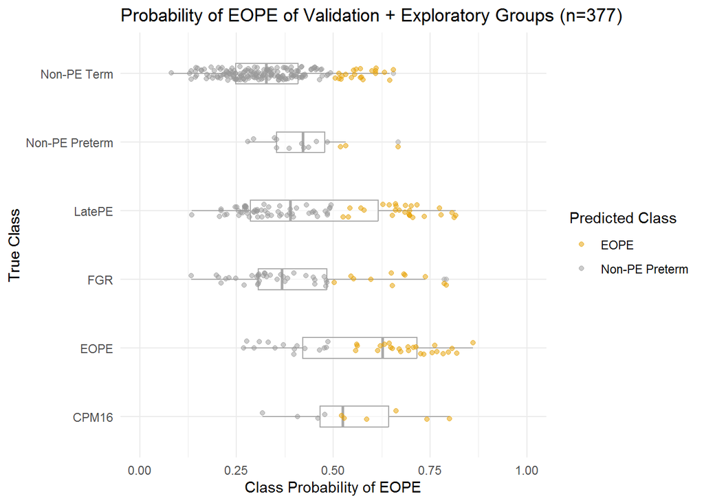

```r
meta %>%
  mutate(True_Class = factor(Class,
                             levels=c("CPM16", "FGR", "LatePE", "Non-PE Term", "Non-PE Preterm", "EOPE"))) %>%
  ggplot() +
  geom_boxplot(aes(x = Class,
                  y = EOPE),
               width=0.3,
               alpha=0.5,
               color="darkgrey") +
  geom_jitter(aes(x = Class,
                  y = EOPE,
                  color = Pred_Class),
              alpha = 0.5,
              position = position_jitter(width = .1)) +
  coord_flip() +
  ylab("Class Probability of EOPE") +
  xlab("True Class") +
  ylim(0,1) +
  scale_color_manual(name = "Predicted Class", values=c("#E69F00", "#999999")) +
  theme_minimal() +
  ggtitle("Probability of EOPE of Validation + Exploratory Groups (n=377)")
```

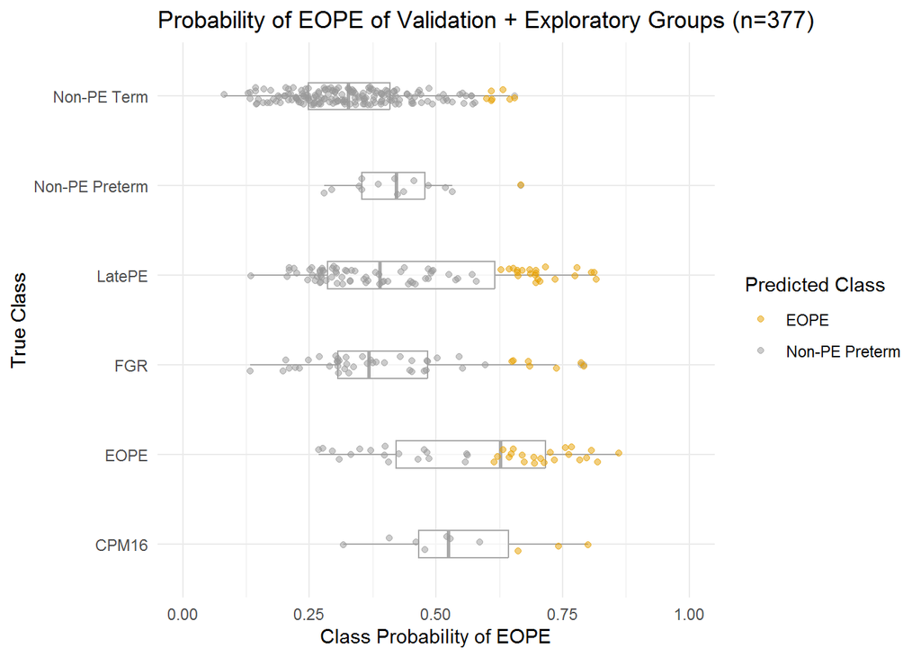

```r
meta %>%
  mutate(True_Class = factor(Class,
                             levels=c("CPM16", "FGR", "LatePE", "Non-PE Term", "Non-PE Preterm", "EOPE"))) %>%
  ggplot() +
  geom_boxplot(aes(x = Class,
                  y = EOPE),
               width=0.3,
               alpha=0.5,
               color="darkgrey") +
  geom_jitter(aes(x = Class,
                  y = EOPE,
                  color = Pred_Class_60),
              alpha = 0.5,
              position = position_jitter(width = .1)) +
  coord_flip() +
  ylab("Class Probability of EOPE") +
  xlab("True Class") +
  ylim(0,1) +
  scale_color_manual(name = "Predicted Class", values=c("#E69F00", "#999999")) +
  theme_minimal() +
  ggtitle("Probability of EOPE of Validation + Exploratory Groups (n=377)")
```

When I don’t batch correct the data, there are several EOPE samples that are misclassified as nPTB. I want to further explore this and be straightforward about the issue in the paper.

```r
# nPTB samples
dim(meta %>% filter(Class == "Non-PE Preterm") %>% filter(Group == "Validation")) # 11
```

```
## [1] 11 38
```